# Using_miscClassify_for_evaluating_properties_of_protein_signatures

Dirk F Moore

2025-04-10

# 1. Introduction

This vignette provides a guide to using the ‘miscClassify’ package to build a classification model using a proposed protein signature and evaluate the predictive accuracy of that model. This vignette requires a current version of the R programming system, and it is recommended that you use the RStudio interface to R. Both are available for free at, respectively,

‘https://cran.r-project.org/bin/windows/base/’ and ‘https://posit.co/download/rstudio-desktop/’ (windows version)

An R version for Apple macOS is also available.

As described in the primary reference, Guzman Rivera et al. (2024), we have data on the relative abundance of 1391 proteins in serum samples for 19 MIS-C patients and 40 patients divided among Kawasaki (13patients), pneumonia (17 patients), and asymptomatic (10 patients). Immunoglobulins were removed from the protein list. The protein abundances were measured using the DIA (data independent acquisition) mass spectrometry procedure. Our goal is to identify protein signatures that distinguish MIS-C patients from the other disease types and calculate measures of predictive accuracy. As explained in Guzman Rivera et al., we propose two three-protein signatures and evaluate their properties. We also use signatures from two previously published papers and evaluate their properties using our data. In addition, the package described here allows users to input their own protein signatures to see how well they work using our data.

The ‘miscPredict’ package takes a proposed protein signature, produces a predictive model using the support vector machine method, and evaluates the resulting model’s ability to distinguish MIS-C from the other disease types. The evaluation includes overall error, sensitivity, specificity, and area under the ROC curve (AUC).

Disclaimer: This package is for research use only.

# 2. Preparing the R system to run the ‘miscClassify’ package.

The ‘miscPredict’ package requires that you first download and install several supporting packages if you haven’t previously installed them. Do this using the ‘install’ function as follows:

```
install.packages(c("e1071", "pROC", "crossval"))
```

Furthermore, to use the ‘miscClassify’ package, you must first download and install the ‘devtools’ package and then, from github, the ‘miscClassify’ package:

```
install.packages("devtools")
devtools::install_github("mooredf22/miscClassify")
```

Next, attach the ‘miscClassify’ package and the associated data of log2-transformed protein abundance levels, and show the first five rows and selected columns (1, 2, 20, 21, 33, 34, 50 and 51) of the data frame. The column names consist of sample type (M for MIS-C, K for Kawasaki, P for pneumonia, and A for asymptomatic) followed by the column number (1 through 59). The row names are a combination of the gene name and protein identifier. The values shown are log2 transformed abundance levels.

```r
library(miscClassify)
library(miscClassify)
data(logMISCdata)
round(logMISCdata[1:5,c(1:2, 20:21,33:34,50:51 )], digits=2)
```

|  | M.1 | M.2 | K.20 | K.21 | P.33 | P.34 | A.50 | A.51 |
| --- | --- | --- | --- | --- | --- | --- | --- | --- |
| HP_P00738 | 30.99 | 31.18 | 26.20 | 30.95 | 24.64 | 31.65 | 30.66 | 29.89 |
| TF_P02787 | 27.94 | 30.14 | 30.32 | 29.61 | 29.63 | 30.07 | 30.10 | 30.80 |
| A2M_P01023 | 29.00 | 29.94 | 30.49 | 29.94 | 29.90 | 30.16 | 30.43 | 30.23 |
| FGB_P02675 | 28.54 | 30.42 | 29.08 | 29.85 | 29.52 | 28.82 | 29.93 | 29.44 |
| SERPINA1_P01009 | 29.80 | 30.48 | 28.81 | 29.96 | 29.84 | 29.41 | 29.51 | 28.54 |

```r
geneList <- matrix(unlist(strsplit(x=rownames(logMISCdata), split ="_")),
                   ncol=2, byrow=TRUE)[,1]
head(geneList)
```

```
#> [1] "HP"       "TF"       "A2M"      "FGB"      "SERPINA1" "FGA"
```

# Obtaining predictions for protein signatures

The first step is to define protein signatures by creating vectors of the corresponding gene names. Here are the two signatures discussed in Guzman Rivera et al. (2024) and also one signature from Nygaard (2024) and one from Yeoh (2024).

```r
geneSet1 <- c("ORM1", "SERPINA3", "AZGP1")  # Jeisac/Gennaro
geneSet2 <- c("VWF", "FCGBP", "SERPINA3")  # Jeisac/Gennaro

geneSetNygaard <- c("FCGR3A", "LCP1", "SERPINA3", "BCHE") #Nygaard (2024)
geneSetYeoh <- c("CD163", "PCSK9")  #Yeoh (2024)
```

Next, we define a binary variable ‘grpInd’ which identifies the samples corresponding to MIS-C and the other samples (Kawasaki, pneumonia, and asymptomatic). Here is the distribution of the four sample groups:

```r
grpIndUse <- matrix(unlist(strsplit(x=names(logMISCdata), split="[.]")),
                    ncol=2, byrow=TRUE)[,1]
table(grpIndUse)
```

```
#> grpIndUse
#>  A  K  M  P
#> 10 13 19 17
```

Since we here focus on comparing MIS-C to the three other groups, we define an indicator variable which is ‘1’ for MIS-C and ‘0’ for the other three comparison groups. We see that there are 19 samples in the MIS-C group and 40 in the comparison group:

```r
grpInd <- as.numeric(grpIndUse == "M")
# 1 indicates MIS-C, 0 indicates Kawasaki, pneumonia, or mild/asymptomatic
table(grpInd)
```

```
#> grpInd
#>  0  1
#> 40 19
```

Finally, the ‘predictSignature’ function uses the signature to fit a support vector machine prediction model and evaluate its predictive (classification) accuracy. We illustrate using geneSet2. A key measure of accuracy is area under the curve (AUC), obtained as follows:

```r
set.seed(424020)
pred.Set2 <- predictSignature(genesUse=geneSet2, geneNames=geneList,
                           grpInd=grpInd, log2out=logMISCdata, cv=TRUE)
```

The output data structure ‘pred.Set2’ contains a number of components relevant to the predictive model. The results for area under the curve are in the ‘out.auc’ component:

```r
pred.Set2$out.auc
```

```
#>        AUC   lowerCI upperCI
#>  0.9565789 0.8959379       1
```

Additional details, including the sensitivity and specificity of the predictive model and also a table of predicted vs original numbers of MIS-C and non-MIS-C subjects, may be seen as follows:

```r
pred.Set2$out.svm
```

```
#> $sens
#>      sens
#> 0.8947368
#>
#> $spec
#>  spec
#> 0.975
#>
#> $tableOut
#>       predictedValues
#> y.orig  0  1
#>      0 39  1
#>      1  2 17
#>
#> $aucOut
#> [1] 0.9565789
#>
#> $aucCI
#> [1] 0.8959379 1.0000000
#>
#> $rocAll
#>
#> Call:
#> roc.default(response = y.orig, predictor = predMatrix[, "1"],     quiet = TRUE, ci = TRUE, smoothed = TRUE)
#>
#> Data: predMatrix[, "1"] in 40 controls (y.orig 0) < 19 cases (y.orig 1).
#> Area under the curve: 0.9566
#> 95% CI: 0.8959-1 (DeLong)
#>
#> $model.orig
#>
#> Call:
#> svm(formula = y.orig ~ ., data = x.orig, probability = TRUE, cross = 5)
#>
#>
#> Parameters:
#>    SVM-Type:  C-classification
#>  SVM-Kernel:  radial
#>        cost:  1
#>
#> Number of Support Vectors:  27
```

To obtain a basic ROC curve, apply the ‘plot’ function to the ‘rocAll’ svm component:

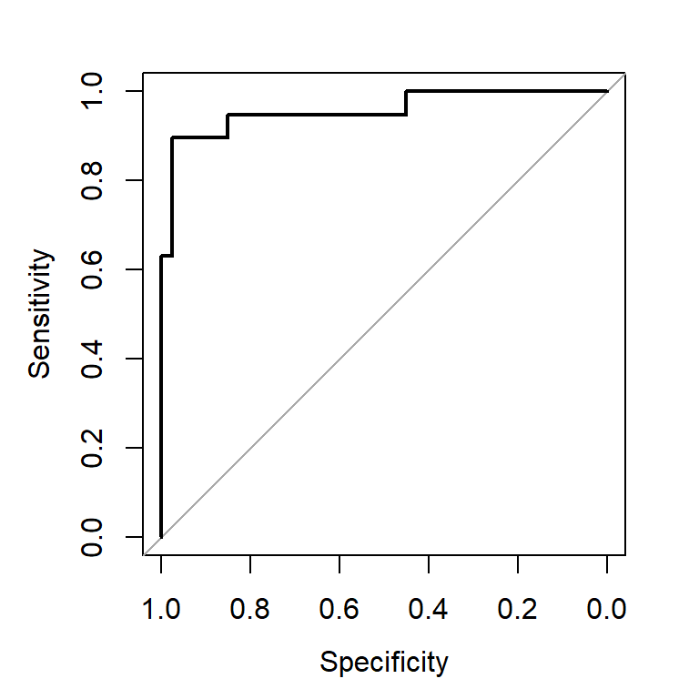

```r
plot(pred.Set2$out.svm$rocAll)
```

An ROC curve with a 95 percent confidence interval may be obtained by first using the ‘ci.se’ function in the pROC package to use a bootstrap calculation method. The ‘specificities=seq(0, 1, 0.01)’ command specifies a list of specificities at which to calculate the confidence limits. Finally, the ‘plot’ function creates the plot. The bootstrap method uses randomly generated bootstrap samples. For reproducibility, one may set the random number seed to a specific number.

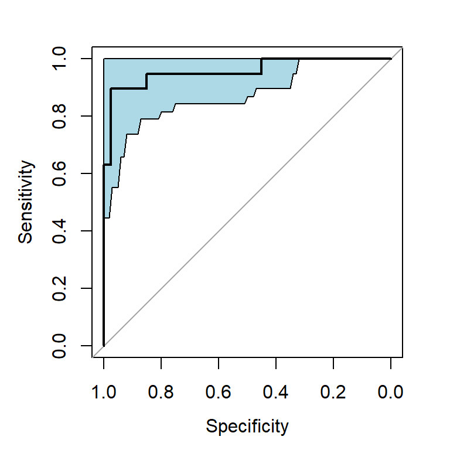

```r
set.seed(109540)
sens.ci <- ci.se(pred.Set2$out.svm$rocAll,
                 boot.n=100, boot.stratified=TRUE,
                 specificities=seq(0, 1, 0.01))
plot(pred.Set2$out.svm$rocAll)
plot(sens.ci, type="shape", col="lightblue")
```

Finally, the results of cross-validation, which corrects for overfitting, may be obtained thus:

```r
pred.Set2$out.cv
```

```
#>      accuracy       sens       spec        AUC
#> [1,] 86.35638 0.73000000 0.92500000 0.93916667
#> [2,]  0.83941 0.05276608 0.02165064 0.01683595
```

The properties of Nygaard’s signature may be obtained by substituting in ‘geneSetNygaard’

```r
set.seed(340863)
pred.Set.Nygaard <- predictSignature(genesUse=geneSetNygaard,
                        geneNames=geneList, grpInd=grpInd,
                        log2out=logMISCdata, cv=TRUE)
pred.Set.Nygaard$out.auc
```

```
#>        AUC   lowerCI  upperCI
#>  0.9078947 0.8331245 0.982665
```

Additional properties may be obtained by entering ‘pred.Set.Nygaard$out.svm' and 'pred.Set.Nygaard$out.cv’ as described above.

# References

Nygaard U, Nielsen AB, Dungu KHS, et al. Proteomic profiling reveals diagnostic signatures and pathogenic insights in multisystem inflammatory syndrome in children. Commun Biol. 2024;7(1):688. doi:10.1038/s42003-024-06370-8

Yeoh S, Estrada-Rivadeneyra D, Jackson H, et al. Plasma Protein Biomarkers Distinguish Multisystem Inflammatory Syndrome in Children From Other Pediatric Infectious and Inflammatory Diseases. Pediatr Infect Dis J. 2024;43(5):444-453. doi:10.1097/INF.0000000000004267

# Reproducibility

Following is the output of the utility `sessionInfo`. This output contains details of the packages and version numbers used to generate these tutorials.

[session information not shown]